# Project Definition & Motivation

Our aim here is to work with big datasets and replicate data management tools in python while doing data analysis. We will combine python with sql because pandas dataframe only works in memory and our dataset is much bigger than our memory can handle. In some of the parts we are going to touch some Natural Language Proccessing libraries and make our dataset smaller and detect languages in comments.

Finally we are going to estimate how much profit we can make from smart ads like google's adsense if we implemented one in this certain website.

Working with big datasets are always a huge challenge and it gives us new opportunities to improve.

# Project Introduction

## About Dataset & Project Literature

Reddit is a discussion website which users can post images and text in a subforum called subreddit which users can discuss about shared contents in comment section. This dataset contains 05/2015 comment submissions from reddit users with 54.504.410 rows and 22 columns.

Columns:

- **CREATED_UTC:** Time when comment was posted
- **UPS:** Positive votes.
- **SUBREDDIT_ID:** Parent subforum(subreddit) id.
- **LINK_ID:** Comments link id.
- **NAME:** Author's id.
- **SCORE_HIDDEN:** Whether their score is hidden or not.
- **AUTHOR_FLAIR_CSS_CLASS:** Subforum moderators can customize their subforums with css codes and every user can use flairs(like profile pictures with texts over it), this is those flair's css class.
- **AUTHOR_FLAIR_TEXT:** Subforum moderators can customize their subforums with css codes and every user can use flairs(like profile pictures with texts over it), this is those flair's text.
- **SUBREDDIT:** Parent subforum's name.
- **ID:** Comment ID.
- **REMOVAL_REASON:** If comment was removed, it's reason.
- **GILDED:** If comment got an award(awards are given by normal people with money), how many award it got.
- **DOWNS:** Negative votes.
- **ARCHIVED:** If comments are older than certain time period they got archived and they become not interactable.
- **AUTHOR:** Which user posted the comment
- **SCORE:** Total votes
- **RETRIEVED_ON:** When the data retrieved on.
- **BODY:** Comment's body.
- **DISTINGUISHED:** If author is well known person or moderator of that particular subreddit their comments become distinguished.
- **EDITED:** If comment was edited when it was edited.
- **CONTROVERSALITY:** Whether comment is controversal or not
- **PARENT_ID:** Users can comment other users comments as well in that case parent comments id will be put here, otherwise contents(posts) ID will be put here.

I got my data from kaggle unfornutely this dataset is too big to run on kaggle so I needed to download it.

> https://www.kaggle.com/reddit/reddit-comments-may-2015/notebooks

If you want a JSON format of this data you can download it from: https://files.pushshift.io/reddit/comments/

# Data Preproccessing

## Accessing data from sqlite and cleaning it

Used this sqlite query to clean the dataset before extracting it to csv because it caused problems while trying to import the data

I didn't import authorflaircss_class field because it is not important for our analysis

```
sqlite
create table reddit_2015_05 as
select
rd.created_utc,
rd.ups,
rd.subreddit_id,
rd.link_id,
rd.name,
rd.score_hidden,
replace(
    replace(
        replace(
                replace(
                    replace(
                        replace(
                            replace(rd.author_flair_text,'\','')
                        ,'*','')
                    ,'#','')
                , X'0A', ' ')
        ,char(13),' ')
    ,';','')
,'"','') as author_flair_text,
rd.subreddit,
rd.id,
rd.removal_reason,
rd.gilded,
rd.downs,
rd.archived,
rd.author,
rd.score,
rd.retrieved_on,
replace(
    replace(
        replace(
                replace(
                    replace(
                        replace(
                            replace(rd.body,'\','')
                        ,'*','')
                    ,'#','')
                , X'0A', ' ')
        ,char(13),' ')
    ,';','')
,'"','') as body,
rd.distinguished,
rd.edited,
rd.controversiality,
rd.parent_id
from may2015 rd;
```

## Splitting csv data to make it ready for import

I needed to split my csv file so I can import it to PostgreSQL because PostgreSQL copy command doesn't support files bigger than 4GB

I used [csvsplitter](https://www.erdconcepts.com/dbtoolbox/csvsplitter/csvsplitter.zip) from [erdconcepts](https://www.erdconcepts.com/dbtoolbox.html)

Opened up cmd and inserted these lines;

```
cmd
cd C:\data\reddit\csvsplitter

CSVSplitter.exe filename="C:\data\reddit\reddit_2015_05.csv" rowcount=5000000
```

It spliced my csv to 11 files ranging from 1.2GB to 1.5GB

## Creating table in PostgreSQL to import our dataset

I created my PostgreSQL table with this query

```
CREATE TABLE "ODS"."EXT_REDDIT_COMMENTS"
(
    created_utc integer,
    ups integer,
    subreddit_id text COLLATE pg_catalog."default",
    link_id text COLLATE pg_catalog."default",
    name text COLLATE pg_catalog."default",
    score_hidden text COLLATE pg_catalog."default",
    author_flair_text text COLLATE pg_catalog."default",
    subreddit text COLLATE pg_catalog."default",
    id text COLLATE pg_catalog."default",
    removal_reason text COLLATE pg_catalog."default",
    gilded integer,
    downs integer,
    archived text COLLATE pg_catalog."default",
    author text COLLATE pg_catalog."default",
    score integer,
    retrieved_on integer,
    body text COLLATE pg_catalog."default",
    distinguished text COLLATE pg_catalog."default",
    edited text COLLATE pg_catalog."default",
    controversiality integer,
    parent_id text COLLATE pg_catalog."default"
)

TABLESPACE pg_default;

ALTER TABLE "ODS"."EXT_REDDIT_COMMENTS"
    OWNER to postgres;
```

## Importing dataset

Then used PostgreSQL copy command to import my data;

```
SET STATEMENT_TIMEOUT TO 3000000;

COPY "ODS"."EXT_REDDIT_COMMENTS" FROM 'C:/data/reddit/REDDIT_2015_05-000.CSV' DELIMITER ';';

COPY "ODS"."EXT_REDDIT_COMMENTS" FROM 'C:/data/reddit/REDDIT_2015_05-001.CSV' DELIMITER ';';

COPY "ODS"."EXT_REDDIT_COMMENTS" FROM 'C:/data/reddit/REDDIT_2015_05-002.CSV' DELIMITER ';';

COPY "ODS"."EXT_REDDIT_COMMENTS" FROM 'C:/data/reddit/REDDIT_2015_05-003.CSV' DELIMITER ';';

COPY "ODS"."EXT_REDDIT_COMMENTS" FROM 'C:/data/reddit/REDDIT_2015_05-004.CSV' DELIMITER ';';

COPY "ODS"."EXT_REDDIT_COMMENTS" FROM 'C:/data/reddit/REDDIT_2015_05-005.CSV' DELIMITER ';';

COPY "ODS"."EXT_REDDIT_COMMENTS" FROM 'C:/data/reddit/REDDIT_2015_05-006.CSV' DELIMITER ';';

COPY "ODS"."EXT_REDDIT_COMMENTS" FROM 'C:/data/reddit/REDDIT_2015_05-007.CSV' DELIMITER ';';

COPY "ODS"."EXT_REDDIT_COMMENTS" FROM 'C:/data/reddit/REDDIT_2015_05-008.CSV' DELIMITER ';';

COPY "ODS"."EXT_REDDIT_COMMENTS" FROM 'C:/data/reddit/REDDIT_2015_05-009.CSV' DELIMITER ';';

COPY "ODS"."EXT_REDDIT_COMMENTS" FROM 'C:/data/reddit/REDDIT_2015_05-010.CSV' DELIMITER ';';

COMMIT;
```

## Analyzing our data for preprocessing

Original dataset is too big to handle(54.504.410 rows with 33.3GB size) maybe we should check if it is possible to reduce our data while not affecting our analysis.

```
SELECT
COUNT(*)
FROM "ODS"."EXT_REDDIT_COMMENTS" ERS
WHERE 1=1
AND LENGTH(ERS.BODY) > 2;
```

This query reduces our data to 54.333.604 rows while removing comments like 'OK' which is not meaningful on its own.

```
SELECT
COUNT(*)
FROM "ODS"."EXT_REDDIT_COMMENTS" ERS
WHERE 1=1
AND LENGTH(ERS.BODY) > 2
AND (LOWER(ERS.AUTHOR) LIKE '%\_bot\_%'
OR LOWER(ERS.AUTHOR) LIKE '%\-bot\-%');
```

This would remove 958 bot comments with comment author names contains "-bot-" or "*bot*", it is not that a huge decrease.

```
SELECT
COUNT(*)
FROM "ODS"."EXT_REDDIT_COMMENTS" ERS
WHERE 1=1
AND LENGTH(ERS.BODY) > 2
AND NOT (LOWER(ERS.AUTHOR) LIKE '%\_bot\_%'
OR LOWER(ERS.AUTHOR) LIKE '%\-bot\-%')
AND NOT(LOWER(REPLACE(ERS.BODY,'''',''))) LIKE '%im a bot%';
```

We could also filter comments with "I'm a bot" text, this also decreases dataset with 24.918 rows.

```
SELECT
COUNT(*)
FROM "ODS"."EXT_REDDIT_COMMENTS" ERS
WHERE 1=1
AND LENGTH(ERS.BODY) > 2
AND NOT (LOWER(ERS.AUTHOR) LIKE '%\_bot\_%'
OR LOWER(ERS.AUTHOR) LIKE '%\-bot\-%')
AND NOT(LOWER(REPLACE(ERS.BODY,'''','')) LIKE '%im a bot%')
AND ERS.BODY <> '[deleted]';
```

This query removes deleted comments which is 3.138.587 rows.

```
SELECT
COUNT(*)
FROM "ODS"."EXT_REDDIT_COMMENTS" ERS
WHERE 1=1
AND LENGTH(ERS.BODY) > 2
AND NOT (LOWER(ERS.AUTHOR) LIKE '%\_bot\_%'
OR LOWER(ERS.AUTHOR) LIKE '%\-bot\-%')
AND NOT(LOWER(REPLACE(ERS.BODY,'''','')) LIKE '%im a bot%')
AND ERS.BODY <> '[deleted]'
AND LENGTH(ERS.REMOVAL_REASON) = 0;
```

We should also remove removed comments which is replaced by removal reason instead of original comments.

```
SELECT
COUNT(*)
FROM "ODS"."EXT_REDDIT_COMMENTS" ERS
WHERE 1=1
AND LENGTH(ERS.BODY) > 2
AND NOT (LOWER(ERS.AUTHOR) LIKE '%\_bot\_%'
OR LOWER(ERS.AUTHOR) LIKE '%\-bot\-%')
AND NOT(LOWER(REPLACE(ERS.BODY,'''','')) LIKE '%im a bot%')
AND ERS.BODY <> '[deleted]'
AND LENGTH(ERS.removal_reason) = 0
AND ERS.BODY LIKE '% %';
```

We should remove single word comments(1.885.966 rows) because they are not important for our analysis.

```
SELECT
COUNT(*)
FROM "ODS"."EXT_REDDIT_COMMENTS" ERS
WHERE 1=1
AND LENGTH(ERS.BODY) > 2
AND NOT (LOWER(ERS.AUTHOR) LIKE '%\_bot\_%'
OR LOWER(ERS.AUTHOR) LIKE '%\-bot\-%')
AND NOT(LOWER(REPLACE(ERS.BODY,'''','')) LIKE '%im a bot%')
AND ERS.BODY <> '[deleted]'
AND LENGTH(ERS.removal_reason) = 0
AND ERS.BODY LIKE '% %'
AND ERS.AUTHOR <> 'AutoModerator';
```

With this query we remove "AutoModerator" user which every subreddit uses it for moderation purposes, It filters 286.444 rows.

```
SELECT
COUNT(*)
FROM "ODS"."EXT_REDDIT_COMMENTS" ERS
WHERE 1=1
AND LENGTH(ERS.BODY) > 2
AND NOT(LOWER(ERS.AUTHOR) LIKE '%\_bot\_%' OR LOWER(ERS.AUTHOR) LIKE '%\-bot\-%')
AND NOT(LOWER(REPLACE(ERS.BODY,'''','')) LIKE '%im a bot%')
AND ERS.BODY <> '[deleted]'
AND LENGTH(ERS.removal_reason) = 0
AND ERS.BODY LIKE '% %'
AND ERS.AUTHOR <> 'AutoModerator'
AND ERS.AUTHOR <> '[deleted]'
```

Filtering authors which they deleted their account removes 305.983 rows.

## Cleaning data

Using sql analysis we found out which data to ignore, we must clean data before working on it.

```python
import pandas as pd
import numpy as np
import psycopg2
import time
import math

conn_string = 'host={pghost} port={pgport} dbname={pgdatabase} user={pguser} password={pgpassword}'.format(pgdatabase='MEF-BDA-PROD',pguser='postgres',pgpassword='123',pghost='localhost',pgport='5432')
conn=psycopg2.connect(conn_string)
cur=conn.cursor()

def check_if_table_exists(schema,table):
    cur.execute("select exists(select * from information_schema.tables where table_schema='{schema}' AND table_name='{table}')".format(schema=schema, table=table))
    return cur.fetchone()[0]

def check_if_index_exists(index):
    cur.execute("SELECT EXISTS(SELECT * FROM PG_CLASS WHERE relname = '{index}')".format(index=index))
    return cur.fetchone()[0]

if(check_if_table_exists('EDW','DWH_REDDIT_COMMENTS')):
    print('Table EDW.DWH_REDDIT_COMMENTS already exists')
else:
    start_time = time.time()
    cur.execute('set time zone UTC;')
    cur.execute("""
    CREATE TABLE "EDW"."DWH_REDDIT_COMMENTS" AS
    SELECT
    ROW_NUMBER() OVER (ORDER BY ERS.ID) AS ID,
    TO_TIMESTAMP(GREATEST(ERS.CREATED_UTC ,CAST(ERS.EDITED AS INTEGER))) AS DATE,
    ERS.SUBREDDIT,
    ERS.AUTHOR,
    ERS.AUTHOR_FLAIR_TEXT,
    ERS.SCORE,
    ERS.BODY AS COMMENT
    FROM "ODS"."EXT_REDDIT_COMMENTS" ERS
    WHERE 1=1
    AND LENGTH(ERS.BODY) > 2
    AND NOT(LOWER(ERS.AUTHOR) LIKE '%\_bot\_%' OR LOWER(ERS.AUTHOR) LIKE '%\-bot\-%')
    AND NOT(LOWER(REPLACE(ERS.BODY,'''','')) LIKE '%im a bot%')
    AND ERS.BODY <> '[deleted]'
    AND LENGTH(ERS.removal_reason) = 0
    AND ERS.BODY LIKE '% %'
    AND ERS.AUTHOR <> 'AutoModerator'
    AND ERS.AUTHOR <> '[deleted]';
    """)
    cur.execute('COMMIT;')
    print("Table EDW.DWH_REDDIT_COMMENTS created in {execute_time} seconds".format(execute_time=math.trunc(time.time()-start_time)))

if(check_if_index_exists('IDX_DWH_REDDIT_COMMENTS#01')):
    print('Index already exists')
else:
    start_time = time.time()
    cur.execute("""
    CREATE INDEX "IDX_DWH_REDDIT_COMMENTS#01"
    ON "EDW"."DWH_REDDIT_COMMENTS" USING BTREE(
        "id" ASC NULLS LAST,
        "date" ASC NULLS LAST
    )
    TABLESPACE PG_DEFAULT;
    """)
    cur.execute('COMMIT;')
    print("Index created in {execute_time} seconds".format(execute_time=math.trunc(time.time()-start_time)))
```

```
Table EDW.DWH_REDDIT_COMMENTS already exists
Index already exists
```

1. We filtered our data and transformed epoch date to readable date and added numeric id to work our data with batch processing. It reduced our row count 54.504.410(with 33.3GB) to 48.690.746(with 24.5GB) with 11% reduction in rows and 27% reduction in size.
2. Added index to increase our read speed from table.

```python
import os
import re
import urllib
from urllib.request import urlopen
import fsspec
import xlrd
import xlsxwriter
from pandas import DataFrame

def download_file_if_not_exists(file_url,file_name):
    start_time = math.trunc(time.time())
    if(os.path.exists(file_name) and os.stat(file_name).st_size==0):
        os.remove(file_name)
    if(not(os.path.exists(file_name))):
        urllib.request.urlretrieve(file_url,file_name)
        with open(file_name, 'r+', errors='ignore', encoding="utf-8") as f:
            file_text = f.read()
            file_text = re.sub(r'"[^"]*"', lambda m: m.group(0).replace(',', ' '), file_text).replace('\\','').replace('"','').replace("'",'')
            f.seek(0)
            f.write(file_text)
            f.truncate()
    end_time = math.trunc(time.time())
    if(start_time!=end_time):
        print("File downloaded and cleaned in {execute_time} seconds".format(execute_time=end_time-start_time))

file_name = "DatafinitiElectronicsProductsPricingData.csv"
file_url = "https://query.data.world/s/n7byb65oqj47oro2btcqqyas62zclv"
download_file_if_not_exists(file_url,file_name)

file_name = "electronic_products_pricing_df.xlsx"
if(os.path.exists(file_name)):
    electronic_products_pricing_df = pd.read_excel(file_name, engine='openpyxl')
else:
    electronic_products_pricing_df = pd.read_csv("DatafinitiElectronicsProductsPricingData.csv", encoding="utf-8")
    electronic_products_pricing_df = electronic_products_pricing_df.loc[:, ~electronic_products_pricing_df.columns.str.contains('^Unnamed')]
    electronic_products_pricing_df = electronic_products_pricing_df[electronic_products_pricing_df["prices.currency"] == "USD"]
    electronic_products_pricing_df = electronic_products_pricing_df[["name","brand","categories","prices.amountMax"]]
    electronic_products_pricing_df = electronic_products_pricing_df.groupby(["name","brand","categories"]).mean()
    electronic_products_pricing_df = electronic_products_pricing_df.reset_index()
    electronic_products_pricing_df = electronic_products_pricing_df.rename(columns = {"prices.amountMax":"average_price"})
    electronic_products_pricing_df["keys"] =  electronic_products_pricing_df[["name","brand","categories"]].agg(' '.join, axis=1, ).str.lower()
    electronic_products_pricing_df.to_excel(file_name, engine='xlsxwriter')

file_name = "keys_pricing_df.xlsx"
if(os.path.exists(file_name)):
    keys_pricing_df = pd.read_excel(file_name, index_col=0, engine='openpyxl')
else:
    keys_pricing_df = DataFrame(electronic_products_pricing_df["keys"].replace('&','').str.split(' ').tolist(), index=electronic_products_pricing_df["average_price"]).stack()
    keys_pricing_df = keys_pricing_df.reset_index()
    keys_pricing_df.columns = ["average_price","level","key"]
    keys_pricing_df = keys_pricing_df[keys_pricing_df["key"] != "&"]
    keys_pricing_df = keys_pricing_df[["key","average_price"]]
    keys_pricing_df["key"] = keys_pricing_df["key"].str.replace(r'[^A-Za-z0-9]+','')
    keys_pricing_df["key"] = keys_pricing_df["key"][~keys_pricing_df["key"].str.isnumeric()]
    keys_pricing_df = keys_pricing_df[keys_pricing_df["key"] != ""] #Used this after realizing dropna doesn't work for some reason
    keys_pricing_df = keys_pricing_df.dropna()
    keys_pricing_df = keys_pricing_df.groupby(["key"]).max()
    keys_pricing_df = keys_pricing_df.reset_index()
    keys_pricing_df = keys_pricing_df.rename(columns = {"average_price":"max_price"})
    keys_pricing_df.to_excel(file_name, engine='xlsxwriter')

keys_pricing_df
```

|  | key | max_price |
| --- | --- | --- |
| 0 | 000mah | 93.374000 |
| 1 | 0g03674 | 209.851250 |
| 2 | 1000watt | 998.326667 |
| 3 | 1000x | 191.996667 |
| 4 | 100400mm | 1574.278571 |
| ... | ... | ... |
| 2926 | zubehr | 58.730000 |
| 2927 | zubie | 99.990000 |
| 2928 | zuxbbweveteztffywrybecztecqtezfbc | 1799.970000 |
| 2929 | zxqyvbwuwyydcq | 18.158000 |
| 2930 | zxsqvcbvvywsrwuaasvczufystyyy | 75.882857 |

2931 rows × 2 columns

We are getting some price and key data to analize how much we would gain if we presented adds based on their comments.

## Removing stopwords and using Natural Language Processing while Detecting Language

Stopwords are commonly used words that must be not stored because they do not give any significant value to analyze. We are going to remove them from our table so we can lower our datasize and proccess our data faster.

We must test which libraries to use and how to use them;

```python
import pycld2

value = 'Testing this value'
print("String '{test_value}' returns: {most_confident_language_tuple}\n".format(test_value=value,most_confident_language_tuple=pycld2.detect(value)[2][0])) #This will return the language with highest confidence score.
value = 'Bu değeri deniyoruz'
print("String '{test_value}' returns: {most_confident_language_tuple}\n".format(test_value=value,most_confident_language_tuple=pycld2.detect(value)[2][0]))
value = 'Test text'
print("String '{test_value}' returns: {most_confident_language_tuple}\n".format(test_value=value,most_confident_language_tuple=pycld2.detect(value)[2][0]))
```

```
String 'Testing this value' returns: ('ENGLISH', 'en', 95, 1077.0)

String 'Bu değeri deniyoruz' returns: ('TURKISH', 'tr', 95, 1706.0)

String 'Test text' returns: ('Unknown', 'un', 0, 0.0)
```

```python
import nltk
import pycld2
from nltk.corpus import stopwords

nltk.download('stopwords', quiet=True)
stop = stopwords.words('english')

sql_command = 'SELECT * FROM "{schema}"."{table}" WHERE ID = 15;'.format(schema='EDW', table='DWH_REDDIT_COMMENTS')
df = pd.read_sql(sql_command,conn)
print("Original comment:\n{comment}\n".format(comment=df['comment'][0]))

df['comment'] = df['comment'].apply(lambda x: ' '.join([word for word in x.lower().split() if word not in (stop)]))

print("Comment after removing stopwords:\n{comment}\n".format(comment=df['comment'][0]))

start_time = time.time()
cur.execute("""
UPDATE "EDW"."DWH_REDDIT_COMMENTS"
SET "comment" = %(comment)s
WHERE "id" = %(id)s
""", {'comment': str(df['comment'][0]), 'id': int(df['id'][0])})

print("Updated record(s) in {execute_time} seconds\n".format(execute_time=math.trunc(time.time()-start_time)))

sql_command = 'SELECT * FROM "{schema}"."{table}" WHERE ID = 15;'.format(schema='EDW', table='DWH_REDDIT_COMMENTS')
df = pd.read_sql(sql_command,conn)
cur.execute('ROLLBACK;')
print("Comment in table:\n{comment}\n\n".format(comment=df['comment'][0]))

df['comment_language_code'] = pycld2.detect(str(df['comment']))[2][0][1]
df['comment_language'] = pycld2.detect(str(df['comment']))[2][0][0].lower().replace('unknown','english')

df
#Since we are testing here we didn't commit to database so our changes are going to be rolled back after our session dies. It will be used after completing our test.
```

```
Original comment:
It's not your fault don't think that. Hey if this helps it does then if it doesn't well. At least I can talk about it.  I shot my dog. I had him for 10 years. I can home from partying and it was New Years so I was going to shoot off my .40 so...  Well I was loading it outside and I shot it off accid…

Comment after removing stopwords:
fault think that. hey helps well. least talk it. shot dog. 10 years. home partying new years going shoot .40 so... well loading outside shot accidentally. right dog. 5-7 tequila shots though go sleep would wake would okay. well called vet shot could saved him. least pain. woke saw dead dog yard… cri…

Updated record(s) in 0 seconds

Comment in table:
fault think that. hey helps well. least talk it. shot dog. 10 years. home partying new years going shoot .40 so... well loading outside shot accidentally. right dog. 5-7 tequila shots though go sleep would wake would okay. well called vet shot could saved him. least pain. woke saw dead dog yard… cri…
```

|  | id | date | subreddit | author | author_flair_text | score | comment | comment_language_code | comment_language |
| --- | --- | --- | --- | --- | --- | --- | --- | --- | --- |
| 0 | 15 | 2015-05-01 00:00:00+00:00 | offmychest | Zekkystyle |  | 14 | fault think that. hey helps well. least talk i... | en | english |

It reduces our data well and it still makes sense.

```python
import nltk
import pycld2
from nltk.corpus import stopwords

nltk.download('stopwords', quiet=True)

sql_command = """SELECT id, date, subreddit, author, replace(author_flair_text,'''','') as author_flair_text, score, replace(COMMENT,'''','') as comment FROM "{schema}"."{table}" WHERE ID BETWEEN 30545495 AND 30545595;""".format(schema='EDW', table='DWH_REDDIT_COMMENTS')
df = pd.read_sql(sql_command,conn)

#30545495 AND 30545595

df['comment_language_code'] = df['comment'].str.replace(r'[^A-Za-z0-9]+',' ').apply(pycld2.detect).apply(lambda x: x[2][0][1])
df['comment_language'] = df['comment'].str.replace(r'[^A-Za-z0-9]+',' ').apply(pycld2.detect).apply(lambda x: x[2][0][0]).str.lower()

def remove_stopwords(text,text_language):
    text_without_stopwords = ' '
    try:
        text_without_stopwords = text_without_stopwords.join([word for word in text.lower().split() if word not in (stopwords.words(text_language))])
    except:
        text_without_stopwords = text_without_stopwords.join([word for word in text.lower().split() if word not in (stopwords.words('english'))])

    text_without_stopwords = re.sub("[\W]"," ",text_without_stopwords,re.UNICODE)
    #text_without_stopwords = re.sub("[^\p{L} 0-9]"," ",text_without_stopwords,re.UNICODE)
    return text_without_stopwords

df['word_count'] = df['comment'].str.count(' ') #We are getting original word count without removing stopwords

df['comment'] = df.apply(lambda x: remove_stopwords(x['comment'], x['comment_language']), axis=1)

df['comment'] = df['comment'].str.replace(',','').replace("'","")
df['author_flair_text'] = df['author_flair_text'].str.replace(',','').replace("'","")

df
```

|  | id | date | subreddit | author | author_flair_text | score | comment | comment_language_code | comment_language | word_count |
| --- | --- | --- | --- | --- | --- | --- | --- | --- | --- | --- |
| 0 | 30545495 | 2015-05-20 12:13:05+00:00 | Turkey | shiguree |  | 1 | i nsana insan yaşama fırsatı verildiğinde şimd... | tr | turkish | 127 |
| 1 | 30545496 | 2015-05-20 12:13:06+00:00 | cats | lovechip |  | 10 | looks like cat used know that sounds like wei... | en | english | 24 |
| 2 | 30545497 | 2015-05-20 12:13:06+00:00 | Database | cojajoc |  | 7 | partitioning table would useful partition da... | en | english | 111 |
| 3 | 30545498 | 2015-05-20 12:13:06+00:00 | unitedkingdom | JamDunc | ex-Yorkshire now Sverige | 11 | well swedens system open run government alth... | en | english | 40 |
| 4 | 30545499 | 2015-05-20 12:13:06+00:00 | skyrim | Open_Info_of94 |  | 2 | lol said role play hard thats real thing | en | english | 12 |
| ... | ... | ... | ... | ... | ... | ... | ... | ... | ... | ... |
| 96 | 30545591 | 2015-05-20 12:13:12+00:00 | Coffee | Italian_Not_Jewish |  | 1 | ive issue brought french press help hard clea... | en | english | 96 |
| 97 | 30545592 | 2015-05-20 12:13:12+00:00 | news | PrivateHazzard |  | 1 | logic incorrect dont need war crime real... | en | english | 19 |
| 98 | 30545593 | 2015-05-20 12:13:12+00:00 | h1z1 | Tenetri |  | 1 | but ive gotten many streamers lt5 viewers bl... | en | english | 37 |
| 99 | 30545594 | 2015-05-20 12:13:12+00:00 | BeforeNAfterAdoption | PantsGiver |  | 14 | inside cats really helps also live fiv cats ... | en | english | 32 |
| 100 | 30545595 | 2015-05-20 12:13:12+00:00 | FlashTV | SuperBattleFranky37 |  | 3 | im curious ciscos source dna tested crime scene | en | english | 16 |

101 rows × 10 columns

```python
import os
import psycopg2
import numpy as np
import psycopg2.extras as extras
from io import StringIO

nltk.download('stopwords', quiet=True)

def df_column_conversation(df, column_name, type):
    if(type == 'timestamp'):
        df[column_name] = df[column_name].apply(lambda x: f"'{x}'::timestamp")
    if(type == 'text'):
        df[column_name] = df[column_name].apply(lambda x: f"'{x}'")

def remove_stopwords(text,text_language):
    text_without_stopwords = ' '
    try:
        text_without_stopwords = text_without_stopwords.join([word for word in text.lower().split() if word not in (stopwords.words(text_language))])
    except:
        text_without_stopwords = text_without_stopwords.join([word for word in text.lower().split() if word not in (stopwords.words('english'))])

    text_without_stopwords = re.sub("[\W]"," ",text_without_stopwords,re.UNICODE)
    return text_without_stopwords

def execute_mogrify(conn, df, schema, table):
    """
    Using cursor.mogrify() to build the bulk insert query
    then cursor.execute() to execute the query
    """
    # Create a list of tupples from the dataframe values
    tuples = [tuple(x) for x in df.to_numpy()]
    # Comma-separated dataframe columns
    cols = ','.join(list(df.columns))
    # SQL quert to execute
    cursor = conn.cursor()
    try:
        for tup in tuples:
            query  = """INSERT INTO "{schema}"."{table}"({cols}) VALUES ({values})""".format(schema=schema,table=table, cols=cols, values=",".join(map(str,tup)))
            cursor.execute(query)
            conn.commit()
    except (Exception, psycopg2.DatabaseError) as error:
        print("Error: %s" % error)
        conn.rollback()
        cursor.close()
        return 1
    #print("execute_mogrify() done")
    cursor.close()

cur.execute('SELECT MAX(ID) FROM "EDW"."DWH_REDDIT_COMMENTS_DETAIL"')
start_row = cur.fetchone()[0]+1
row_per_loop = 10000
cur.execute('SELECT COUNT(1) FROM "EDW"."DWH_REDDIT_COMMENTS"')
end_row = cur.fetchone()[0]

start_time = math.trunc(time.time())
for i in range(start_row,end_row,row_per_loop):
    sql_command = """SELECT id, date, subreddit, author, replace(author_flair_text,'''','') as author_flair_text, score, replace(COMMENT,'''','') as comment FROM "{schema}"."{table}" WHERE ID BETWEEN {start_row} AND {end_row};""".format(schema='EDW', table='DWH_REDDIT_COMMENTS', start_row=i, end_row=i+row_per_loop-1)
    df = pd.read_sql(sql_command,conn)
    df['comment_language_code'] = df['comment'].str.replace(r'[^A-Za-z0-9]+',' ').apply(pycld2.detect).apply(lambda x: x[2][0][1])
    df['comment_language'] = df['comment'].str.replace(r'[^A-Za-z0-9]+',' ').apply(pycld2.detect).apply(lambda x: x[2][0][0]).str.lower()
    df['word_count'] = df['comment'].str.count(' ') #We are getting original word count without removing stopwords
    df['comment'] = df.apply(lambda x: remove_stopwords(x['comment'], x['comment_language']), axis=1)
    df['comment'] = df['comment'].str.replace(',','')
    df['author_flair_text'] = df['author_flair_text'].str.replace(',','')
    df_column_conversation(df, 'date', 'timestamp')
    df_column_conversation(df, 'subreddit', 'text')
    df_column_conversation(df, 'author', 'text')
    df_column_conversation(df, 'author_flair_text', 'text')
    df_column_conversation(df, 'comment', 'text')
    df_column_conversation(df, 'comment_language_code', 'text')
    df_column_conversation(df, 'comment_language', 'text')
    execute_mogrify(conn,df,"EDW","DWH_REDDIT_COMMENTS_DETAIL")
    print("Inserted rows between {start_row} and {end_row}".format(start_row=i, end_row=i+row_per_loop-1))

end_time = math.trunc(time.time())
print("Data transformation completed in {execute_time} seconds.".format(execute_time=end_time-start_time))
```

```
Data transformation completed in 0 seconds.
```

Inserting about 15,000,000 rows took about 11.13 hours. Data processing in this part took tremendous amount of time.

# Data Analysis & Data Visualizations

## Top 20 Most Commented Subreddits on Average

In this analysis we are going to see most commented subreddits on average. We are going to ignore subreddits which has less than 200 comments because they might be skewed from low comment count.

```python
if(check_if_table_exists('EDW','DWH_REDDIT_SUBREDDIT_COMMENTS')):
    print('Table EDW.DWH_REDDIT_SUBREDDIT_COMMENTS already exists')
else:
    start_time = math.trunc(time.time())
    cur.execute("""
    CREATE TABLE "EDW"."DWH_REDDIT_SUBREDDIT_COMMENTS" AS
    SELECT
    SUBREDDIT,
    AVG(WORD_COUNT) AS AVERAGE_WORD_COUNT,
    MIN(WORD_COUNT) AS MINIMUM_WORD_COUNT,
    MAX(WORD_COUNT) AS MAXIMUM_WORD_COUNT,
    COUNT(*) AS COMMENT_COUNT
    FROM "EDW"."DWH_REDDIT_COMMENTS_DETAIL"
    GROUP BY SUBREDDIT;
    """)
    end_time = math.trunc(time.time())
    cur.execute('COMMIT;')
    print("Table EDW.DWH_REDDIT_SUBREDDIT_COMMENTS created in {execute_time} seconds".format(execute_time=end_time-start_time))
```

```
Table EDW.DWH_REDDIT_SUBREDDIT_COMMENTS already exists
```

```python
sql_command = """
SELECT
*
FROM "EDW"."DWH_REDDIT_SUBREDDIT_COMMENTS"
WHERE 1=1
AND COMMENT_COUNT >= 200
ORDER BY AVERAGE_WORD_COUNT DESC;
"""
df_subreddit_comments = pd.read_sql(sql_command,conn)
df_subreddit_comments['average_word_count'] = df_subreddit_comments['average_word_count'].apply(round)
df_subreddit_comments.head(20)
```

|  | subreddit | average_word_count | minimum_word_count | maximum_word_count | comment_count |
| --- | --- | --- | --- | --- | --- |
| 0 | subredditreports | 503 | 1 | 1135 | 3303 |
| 1 | dancing | 473 | 1 | 2044 | 663 |
| 2 | dailyprogrammer | 344 | 1 | 5024 | 1577 |
| 3 | cissp | 344 | 1 | 1943 | 311 |
| 4 | csgocritic | 323 | 1 | 2002 | 239 |
| 5 | DanceDanceRevolution | 299 | 1 | 3640 | 1007 |
| 6 | JonTronCirclejerk | 283 | 1 | 3332 | 245 |
| 7 | DestructiveReaders | 234 | 1 | 1986 | 1532 |
| 8 | Kochen | 198 | 1 | 1021 | 221 |
| 9 | kundalini | 183 | 1 | 1636 | 218 |
| 10 | Worldprompts | 171 | 1 | 1746 | 537 |
| 11 | PSYC2371 | 170 | 1 | 1103 | 709 |
| 12 | IronThroneRP | 170 | 1 | 1625 | 2512 |
| 13 | Dance | 169 | 1 | 2069 | 506 |
| 14 | SeireiteiRP | 162 | 1 | 757 | 223 |
| 15 | Oneirosophy | 160 | 1 | 1225 | 630 |
| 16 | WritingPrompts | 155 | 1 | 3224 | 44070 |
| 17 | Target | 147 | 1 | 1698 | 995 |
| 18 | Sikh | 145 | 1 | 1665 | 1159 |
| 19 | ReasonableFaith | 145 | 1 | 1802 | 1429 |

## Hourly Comment

```python
if(check_if_table_exists('EDW','DWH_REDDIT_HOURLY_COMMENTS')):
    print('Table EDW.DWH_REDDIT_HOURLY_COMMENTS already exists')
else:
    start_time = math.trunc(time.time())
    cur.execute("""
    CREATE TABLE "EDW"."DWH_REDDIT_HOURLY_COMMENTS" AS
    WITH COMMENT_HOURLY AS(
    SELECT
    EXTRACT('HOUR' FROM DATE) AS UTC_HOUR,
    COUNT(*) AS COMMENT_COUNT
    FROM "EDW"."DWH_REDDIT_COMMENTS_DETAIL"
    WHERE 1=1
    GROUP BY EXTRACT('HOUR' FROM DATE)
    )
    SELECT
    CH.*,
    SUM(COMMENT_COUNT) OVER() AS TOTAL_COMMENT_COUNT,
    COMMENT_COUNT/SUM(COMMENT_COUNT) OVER() AS PERCENTAGE
    FROM COMMENT_HOURLY CH;
    """)
    end_time = math.trunc(time.time())
    cur.execute('COMMIT;')
    print("Table EDW.DWH_REDDIT_HOURLY_COMMENTS created in {execute_time} seconds".format(execute_time=end_time-start_time))
```

```
Table EDW.DWH_REDDIT_HOURLY_COMMENTS already exists
```

```python
sql_command = """
SELECT
*
FROM "EDW"."DWH_REDDIT_HOURLY_COMMENTS";
"""
df_hourly_comments = pd.read_sql(sql_command,conn)
df_hourly_comments['percentage'] = round(df_hourly_comments['percentage'],ndigits=4)*100
df_hourly_comments.head(24)
```

|  | utc_hour | comment_count | total_comment_count | percentage |
| --- | --- | --- | --- | --- |
| 0 | 0.0 | 2391819 | 48690748.0 | 4.91 |
| 1 | 1.0 | 2434179 | 48690748.0 | 5.00 |
| 2 | 2.0 | 2387353 | 48690748.0 | 4.90 |
| 3 | 3.0 | 2150783 | 48690748.0 | 4.42 |
| 4 | 4.0 | 1906910 | 48690748.0 | 3.92 |
| 5 | 5.0 | 1525142 | 48690748.0 | 3.13 |
| 6 | 6.0 | 1340774 | 48690748.0 | 2.75 |
| 7 | 7.0 | 1136063 | 48690748.0 | 2.33 |
| 8 | 8.0 | 998797 | 48690748.0 | 2.05 |
| 9 | 9.0 | 938141 | 48690748.0 | 1.93 |
| 10 | 10.0 | 1004587 | 48690748.0 | 2.06 |
| 11 | 11.0 | 1208687 | 48690748.0 | 2.48 |
| 12 | 12.0 | 1519600 | 48690748.0 | 3.12 |
| 13 | 13.0 | 1924457 | 48690748.0 | 3.95 |
| 14 | 14.0 | 2293496 | 48690748.0 | 4.71 |
| 15 | 15.0 | 2527095 | 48690748.0 | 5.19 |
| 16 | 16.0 | 2628807 | 48690748.0 | 5.40 |
| 17 | 17.0 | 2729762 | 48690748.0 | 5.61 |
| 18 | 18.0 | 2727110 | 48690748.0 | 5.60 |
| 19 | 19.0 | 2747001 | 48690748.0 | 5.64 |
| 20 | 20.0 | 2732594 | 48690748.0 | 5.61 |
| 21 | 21.0 | 2600597 | 48690748.0 | 5.34 |
| 22 | 22.0 | 2462657 | 48690748.0 | 5.06 |
| 23 | 23.0 | 2374337 | 48690748.0 | 4.88 |

## Comments in Hours of Day

```python
import matplotlib.pyplot as plt
plt.style.use('seaborn-whitegrid')

plt.plot(df_hourly_comments['utc_hour'], df_hourly_comments['comment_count'])
plt.xlabel('Hour(UTC)')
plt.ylabel('Comments(m)')
plt.title('Comments in Hours of Day')
```

[figure not shown]

While this analysis made some sense we can't exactly understand it because timezones are in UTC and it is worldwide.

```python
if(check_if_table_exists('EDW','DWH_REDDIT_LANGUAGE_HOURLY_COMMENTS')):
    print('Table EDW.DWH_REDDIT_LANGUAGE_HOURLY_COMMENTS already exists')
else:
    start_time = math.trunc(time.time())
    cur.execute("""
    CREATE TABLE "EDW"."DWH_REDDIT_LANGUAGE_HOURLY_COMMENTS" AS
    WITH COMMENT_HOURLY AS(
    SELECT
    COMMENT_LANGUAGE_CODE AS LANGUAGE_CODE,
    COMMENT_LANGUAGE AS LANGUAGE,
    EXTRACT('HOUR' FROM DATE) AS UTC_HOUR,
    COUNT(*) AS COMMENT_COUNT
    FROM "EDW"."DWH_REDDIT_COMMENTS_DETAIL"
    WHERE 1=1
    GROUP BY
    COMMENT_LANGUAGE_CODE,
    COMMENT_LANGUAGE,
    EXTRACT('HOUR' FROM DATE)
    )
    SELECT
    CH.*,
    SUM(COMMENT_COUNT) OVER(PARTITION BY LANGUAGE_CODE) AS TOTAL_COMMENT_COUNT,
    COMMENT_COUNT/SUM(COMMENT_COUNT) OVER(PARTITION BY LANGUAGE_CODE) AS PERCENTAGE
    FROM COMMENT_HOURLY CH;
    """)
    end_time = math.trunc(time.time())
    cur.execute('COMMIT;')
    print("Table EDW.DWH_REDDIT_LANGUAGE_HOURLY_COMMENTS created in {execute_time} seconds".format(execute_time=end_time-start_time))
```

```
Table EDW.DWH_REDDIT_LANGUAGE_HOURLY_COMMENTS already exists
```

```python
sql_command = """
SELECT
*
FROM "EDW"."DWH_REDDIT_LANGUAGE_HOURLY_COMMENTS"
WHERE LANGUAGE_CODE = 'tr';
"""
df_hourly_language_comments = pd.read_sql(sql_command,conn)
df_hourly_language_comments['percentage'] = round(df_hourly_language_comments['percentage'],ndigits=4)*100
df_hourly_language_comments['gmt_p3_hour'] = df_hourly_language_comments['utc_hour']+3%24

plt.plot(df_hourly_language_comments['gmt_p3_hour'], df_hourly_language_comments['comment_count'])
plt.xlabel('Hour(GMT+3)')
plt.ylabel('Comments')
plt.title('Comments in Hours of Day at Turkey')
```

[figure not shown]

We can clearly see that around 17:00 there is a huge increase of comments, this is probably caused by people leaving from work/school and have free time.

At 21:00 comment count peaks at it's highest then starts to decline because people starting to sleep.

## Most popular languages and frequent words in WorldNews

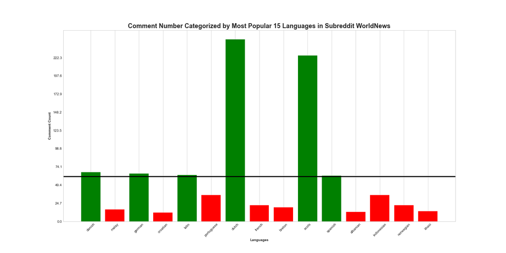

```python
from PIL import Image
import os.path

def check_if_file_exists(filepath):
    return os.path.isfile(filepath)

if(not(check_if_file_exists('images/comment_number_languages_worldnews.png'))):
    sql_command = """
        SELECT
        COMMENT_LANGUAGE AS LANGUAGE,
        COUNT(*) AS COMMENT_COUNT
        FROM "EDW"."DWH_REDDIT_COMMENTS_DETAIL"
        WHERE 1=1
        AND COMMENT_LANGUAGE_CODE NOT IN ('en','un')
        AND SUBREDDIT = 'worldnews'
        GROUP BY COMMENT_LANGUAGE
        ORDER BY COUNT(*) DESC
        LIMIT 15;
        """
    df_language_count_bar = pd.read_sql(sql_command,conn)
    df_language_count_bar = df_language_count_bar.sample(frac=1) #Shuffle dataframe

    plt.bar(df_language_count_bar['language'],df_language_count_bar['comment_count'],color=np.where(df_language_count_bar['comment_count']>=df_language_count_bar['comment_count'].mean(),'green','red'))
    plt.ylabel('Comment Count',fontweight='bold',rotation=90)
    plt.xlabel('Languages',fontweight='bold')
    plt.title('Comment Number Categorized by Most Popular 15 Languages in Subreddit WorldNews',fontweight='bold',fontsize=18)
    plt.xticks(rotation=45)
    plt.yticks(np.arange(0,df_language_count_bar['comment_count'].max(),step=df_language_count_bar['comment_count'].max()/10))
    plt.grid(axis='y')
    plt.axhline(y=df_language_count_bar['comment_count'].mean(),color='black',linewidth=3)
    plt.savefig('images/comment_number_languages_worldnews.png')
    plt.close()
Image.open('images/comment_number_languages_worldnews.png')
```

Subreddit WorldNews where every user can share global news and most popular language is english thats why we are exluding english language in this graph and looking for other most popular languages in this subreddit.

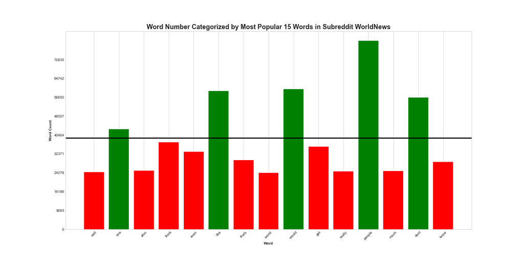

```python
if(not(check_if_file_exists('images/word_number_worldnews.png'))):
    sql_command = """
        SELECT
        WORD,
        SUM(WORD_COUNT) AS WORD_COUNT
        FROM "EDW"."DWH_REDDIT_SUBREDDIT_LANGUAGE_WORD"
        WHERE 1=1
        AND SUBREDDIT = 'worldnews'
        AND COMMENT_LANGUAGE = 'english'
        AND TRIM(WORD) IS NOT NULL
        AND LENGTH(TRIM(WORD)) > 2
        AND NOT(TRIM(WORD) ~ '^([0-9]+[.]?[0-9]*|[.][0-9]+)$')
        GROUP BY WORD
        ORDER BY SUM(WORD_COUNT) DESC
        LIMIT 15;
        """
    df_word_count_bar = pd.read_sql(sql_command,conn)
    df_word_count_bar = df_word_count_bar.sample(frac=1) #Shuffle dataframe

    plt.bar(df_word_count_bar['word'],df_word_count_bar['word_count'],color=np.where(df_word_count_bar['word_count']>=df_word_count_bar['word_count'].mean(),'green','red'))
    plt.ylabel('Word Count',fontweight='bold',rotation=90)
    plt.xlabel('Word',fontweight='bold')
    plt.title('Word Number Categorized by Most Popular 15 Words in Subreddit WorldNews',fontweight='bold',fontsize=18)
    plt.xticks(rotation=45)
    plt.yticks(np.arange(0,df_word_count_bar['word_count'].max(),step=df_word_count_bar['word_count'].max()/10))
    plt.grid(axis='y')
    plt.axhline(y=df_word_count_bar['word_count'].mean(),color='black',linewidth=3)
    plt.savefig('images/word_number_worldnews.png')
    plt.close()
Image.open('images/word_number_worldnews.png')
```

In this plot we are looking at most popular 15 words in worldnews subreddit in English language.

## End Goal - Smart Marketing Analytics

For our end goal we are going split every comment word by word and assume we are showing ads to our customers based on their comments and we sell every 5% of the ads we show to our customers. We must **estimate** how much profit we can get based on our predictions.

```python
if(check_if_table_exists('EDW','TRF_REDDIT_SUBREDDIT_LANGUAGE_WORD') or check_if_table_exists('EDW','DWH_REDDIT_SUBREDDIT_LANGUAGE_WORD')):
    print('Table EDW.TRF_REDDIT_SUBREDDIT_LANGUAGE_WORD or EDW.DWH_REDDIT_SUBREDDIT_LANGUAGE_WORD already exists')
else:
    start_time = math.trunc(time.time())
    cur.execute("""
    CREATE TABLE "EDW"."TRF_REDDIT_SUBREDDIT_LANGUAGE_WORD" AS
    SELECT
    subreddit,
    comment_language,
    regexp_split_to_table(comment, '\s+(\w\s+)*') AS WORD
    FROM "EDW"."DWH_REDDIT_COMMENTS_DETAIL"
    """)
    end_time = math.trunc(time.time())
    cur.execute('COMMIT;')
    print("Table EDW.TRF_REDDIT_SUBREDDIT_LANGUAGE_WORD created in {execute_time} seconds".format(execute_time=end_time-start_time))
```

```
Table EDW.TRF_REDDIT_SUBREDDIT_LANGUAGE_WORD or EDW.DWH_REDDIT_SUBREDDIT_LANGUAGE_WORD already exists
```

After our analysis we are just going to drop this table because it's size is 98,8GB(transformed in 18.5 min)

```python
if(check_if_table_exists('EDW','DWH_REDDIT_SUBREDDIT_LANGUAGE_WORD')):
    print('Table EDW.DWH_REDDIT_SUBREDDIT_LANGUAGE_WORD already exists')
else:
    start_time = math.trunc(time.time())
    cur.execute("""
    CREATE TABLE "EDW"."DWH_REDDIT_SUBREDDIT_LANGUAGE_WORD" AS
    SELECT
    subreddit,
    comment_language,
    word,
    COUNT(*) AS word_count
    FROM "EDW"."TRF_REDDIT_SUBREDDIT_LANGUAGE_WORD"
    GROUP BY subreddit,
    comment_language,
    word;
    DROP TABLE "EDW"."TRF_REDDIT_SUBREDDIT_LANGUAGE_WORD";
    """)
    end_time = math.trunc(time.time())
    cur.execute('COMMIT;')
    print("Table EDW.DWH_REDDIT_SUBREDDIT_LANGUAGE_WORD created in {execute_time} seconds".format(execute_time=end_time-start_time))
```

```
Table EDW.DWH_REDDIT_SUBREDDIT_LANGUAGE_WORD already exists
```

Transforming this dataset took around 1 hour.

```python
if(check_if_table_exists('EDW','DWH_ELECTRONIC_PRICES')):
    print('Table EDW.DWH_ELECTRONIC_PRICES already exists.')
else:
    start_time = math.trunc(time.time())
    cur.execute("""
    CREATE TABLE "EDW"."DWH_ELECTRONIC_PRICES"
    (
    key text,
    max_price numeric
    );

    ALTER TABLE "EDW"."DWH_ELECTRONIC_PRICES"
    OWNER to postgres;
    """)
    end_time = math.trunc(time.time())
    cur.execute('COMMIT;')
    print("Table EDW.DWH_ELECTRONIC_PRICES created in {execute_time} seconds.".format(execute_time=end_time-start_time))

cur.execute('SELECT COUNT(*) FROM "EDW"."DWH_ELECTRONIC_PRICES"')
table_count = cur.fetchone()[0]
data_frame_count = len(keys_pricing_df.index)

if(table_count<data_frame_count):
    start_time = math.trunc(time.time())
    keys_pricing_df['key'] = keys_pricing_df['key'].str.replace("'",'')
    df_column_conversation(keys_pricing_df, 'key', 'text')
    execute_mogrify(conn,keys_pricing_df,"EDW","DWH_ELECTRONIC_PRICES")
    end_time = math.trunc(time.time())
    print("Data import to EDW.DWH_ELECTRONIC_PRICES completed in {execute_time} seconds.".format(execute_time=end_time-start_time))
else:
    print("Data already imported to EDW.DWH_ELECTRONIC_PRICES")
```

```
Table EDW.DWH_ELECTRONIC_PRICES already exists.
Data already imported to EDW.DWH_ELECTRONIC_PRICES
```

```python
if(check_if_table_exists('EDW','DWH_TOTAL_PRICE_BY_WORDS')):
    print('Table EDW.DWH_TOTAL_PRICE_BY_WORDS already exists.')
else:
    start_time = math.trunc(time.time())
    cur.execute("""
    CREATE TABLE "EDW"."DWH_TOTAL_PRICE_BY_WORDS" AS
    SELECT
    SLW.*,
    ROUND(PRC.MAX_PRICE) AS PRICE_PER_ITEM,
    ROUND(SLW.WORD_COUNT*PRC.MAX_PRICE) AS TOTAL_PRICE
    FROM "EDW"."DWH_REDDIT_SUBREDDIT_LANGUAGE_WORD" SLW
    INNER JOIN "EDW"."DWH_ELECTRONIC_PRICES" PRC ON (SLW.word = PRC.key);
    """)
    end_time = math.trunc(time.time())
    cur.execute('COMMIT;')
    print("Table EDW.DWH_TOTAL_PRICE_BY_WORDS created in {execute_time} seconds.".format(execute_time=end_time-start_time))
```

```
Table EDW.DWH_TOTAL_PRICE_BY_WORDS already exists.
```

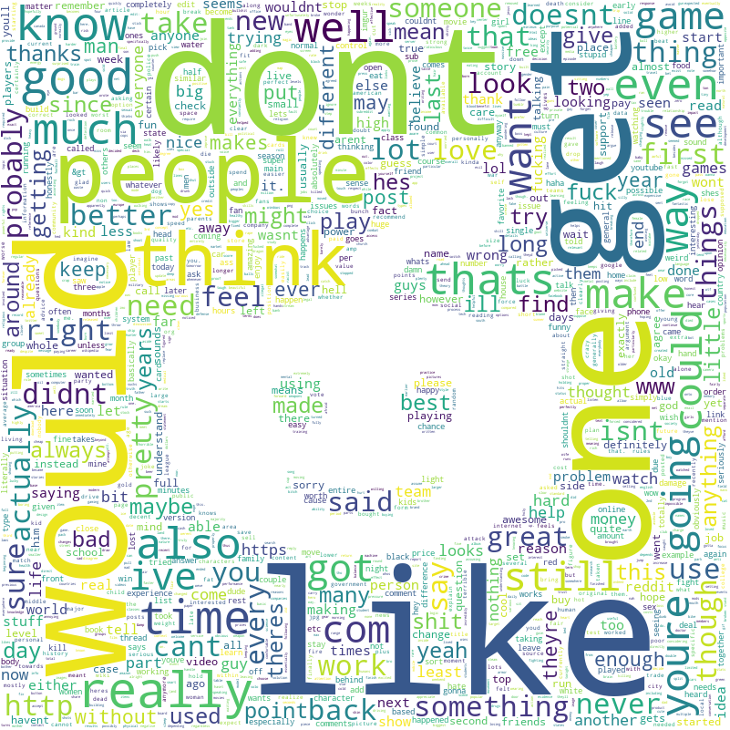

```python
from wordcloud import WordCloud
import matplotlib.image as mpimg

if(not(check_if_file_exists('images/word_cloud_by_count_all.png'))):
    sql_command = """
    SELECT
    WORD,
    SUM(WORD_COUNT) AS WORD_COUNT
    FROM "EDW"."DWH_REDDIT_SUBREDDIT_LANGUAGE_WORD"
    WHERE 1=1
    AND TRIM(WORD) IS NOT NULL
    AND LENGTH(TRIM(WORD)) > 2
    AND NOT(TRIM(WORD) ~ '^([0-9]+[.]?[0-9]*|[.][0-9]+)$')
    GROUP BY WORD
    ORDER BY SUM(WORD_COUNT) DESC;
    """
    df_word_cloud = pd.read_sql(sql_command,conn)

    reddit_mask = np.array(Image.open('images/reddit.png'))
    word_cloud_data = dict(zip(df_word_cloud['word'].tolist(), df_word_cloud['word_count'].tolist()))

    wc = WordCloud(background_color='white', width=8000, height=4000, max_words=10000, mask=reddit_mask).generate_from_frequencies(word_cloud_data)
    wc.to_file('images/word_cloud_by_count_all.png')
Image.open('images/word_cloud_by_count_all.png')
```

Word cloud based on word counts where words are more than 2 characters and not numeric.

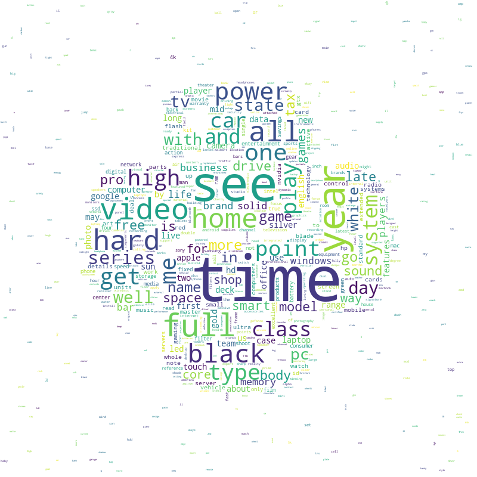

```python
if(not(check_if_file_exists('images/word_cloud_by_value_all.png'))):
    sql_command = """
    SELECT
    WORD,
    SUM(TOTAL_PRICE) AS TOTAL_PRICE
    FROM "EDW"."DWH_TOTAL_PRICE_BY_WORDS"
    GROUP BY WORD
    ORDER BY SUM(TOTAL_PRICE) DESC;
    """
    df_word_cloud = pd.read_sql(sql_command,conn)

    python_mask = np.array(Image.open('images/python.jpg'))
    word_cloud_data = dict(zip(df_word_cloud['word'].tolist(), df_word_cloud['total_price'].tolist()))

    wc = WordCloud(background_color='white', width=8000, height=4000, max_words=10000, mask=python_mask).generate_from_frequencies(word_cloud_data)
    wc.to_file('images/word_cloud_by_value_all.png')
Image.open('images/word_cloud_by_value_all.png')
```

Word cloud based on total price.

```python
cur.execute("""
SELECT
SUM(TOTAL_PRICE) AS TOTAL_PRICE
FROM "EDW"."DWH_TOTAL_PRICE_BY_WORDS"
ORDER BY SUM(TOTAL_PRICE) DESC
LIMIT 200;
""")
total_price = float(cur.fetchone()[0])
print("""From this analysis we could potential sell {total_price:,}$ of value items.
If we assume we can sell only 5% items from customers we show ad based on their comments we could sell {estimated_price_value_from_ads:,}$ of value.
However this doesn't calculates net gain or sites gain from profit if we assume manufacturers get %20 percent profit per item and each successful purchase is shared with website that shows the ad by 1% we can assume that website would gain {website_profit:,}$ monthly.""".format(total_price=total_price, estimated_price_value_from_ads=round(total_price*0.05),website_profit=round(total_price*0.05*0.2*0.01)))
```

```
From this analysis we could potential sell 103,426,338,391.0$ of value items.
If we assume we can sell only 5% items from customers we show ad based on their comments we could sell 5,171,316,920$ of value.
However this doesn't calculates net gain or sites gain from profit if we assume manufacturers get %20 percent profit per item and each successful purchase is shared with website that shows the ad by 1% we can assume that website would gain 10,342,634$ monthly.
```

```python
cur.close()
conn.close()
```

# Sources:

1. [About Reddit](https://en.wikipedia.org/wiki/Reddit)
2. [Data source](https://www.kaggle.com/reddit/reddit-comments-may-2015/notebooks)
3. [Checking if a table exist with psycopg2 on postgreSQL](https://stackoverflow.com/questions/1874113/checking-if-a-postgresql-table-exists-under-python-and-probably-psycopg2)
4. [Using current time in UTC as default value in PostgreSQL. This is important because date is utc in the data](https://stackoverflow.com/questions/16609724/using-current-time-in-utc-as-default-value-in-postgresql)
5. [Creating multicolumn index on PostgreSQL](https://www.postgresql.org/docs/9.6/indexes-multicolumn.html)
6. [Checking if index exist](https://stackoverflow.com/questions/45983169/checking-for-existence-of-index-in-postgresql)
7. [How to execute start time and end time in python](https://www.codegrepper.com/code-examples/delphi/how+to+execute+from+start+time+to+end+time+in+python)
8. [Truncating numbers in python](https://www.w3schools.com/python/ref_math_trunc.asp)
9. [Removing stopwords](https://stackoverflow.com/questions/29523254/python-remove-stop-words-from-pandas-dataframe)
10. [Prevent SQL Injection in Python](https://realpython.com/prevent-python-sql-injection/)
11. [Preventing SQL Injection resulted errors but It needed to be done, data type conversation is the key here](https://stackoverflow.com/questions/39564755/programmingerror-psycopg2-programmingerror-cant-adapt-type-numpy-ndarray)
12. [About stopwords](https://www.geeksforgeeks.org/removing-stop-words-nltk-python/)
13. [How to detect language](https://github.com/aboSamoor/pycld2)
14. [Increasing timeout while installing new packages](https://stackoverflow.com/questions/43298872/how-to-solve-readtimeouterror-httpsconnectionpoolhost-pypi-python-org-port)
15. [PyCld2 is only works in linux systems](https://www.lfd.uci.edu/~gohlke/pythonlibs/)
16. [Replacing text to change unknown values to english](https://stackoverflow.com/questions/28986489/how-to-replace-text-in-a-column-of-a-pandas-dataframe)
17. [Electronic Products and Pricing Data](https://data.world/datafiniti/electronic-products-and-pricing-data/workspace/file?filename=DatafinitiElectronicsProductsPricingData.csv)
18. [Remove all commas between quotes](https://stackoverflow.com/questions/38336518/remove-all-commas-between-quotes)
19. [Check if file exist in directory](https://stackoverflow.com/questions/28144529/how-to-check-if-file-already-exists-if-not-download-on-python)
20. [Download files](https://stackabuse.com/download-files-with-python/)
21. [Deleting empty files](https://stackoverflow.com/questions/48046729/delete-empty-files)
22. [Removing unnamed columns](https://stackoverflow.com/questions/43983622/remove-unnamed-columns-in-pandas-dataframe)
23. [Split (explode) pandas dataframe string entry to separate rows](https://stackoverflow.com/questions/12680754/split-explode-pandas-dataframe-string-entry-to-separate-rows)
24. [Dropping numeric values](https://stackoverflow.com/questions/48636170/dropping-numeric-rows-from-dataframe-in-python)
25. [Join function](https://www.geeksforgeeks.org/join-function-python/)
26. [Apply function with two arguments to columns](https://stackoverflow.com/questions/34279378/python-pandas-apply-function-with-two-arguments-to-columns)
27. [Pandas to PostgreSQL using Psycopg2: Bulk Insert Performance Benchmark](https://naysan.ca/2020/05/09/pandas-to-postgresql-using-psycopg2-bulk-insert-performance-benchmark/)
28. [Print number with commas as thousands separators](https://stackoverflow.com/questions/1823058/how-to-print-number-with-commas-as-thousands-separators)
29. [How to create a wordcloud according to frequencies in a pandas dataframe](https://stackoverflow.com/questions/57826063/how-to-create-a-wordcloud-according-to-frequencies-in-a-pandas-dataframe)
30. [Choosing the right colormaps](https://matplotlib.org/3.3.3/tutorials/colors/colormaps.html)